# Solutions for Regression

Dr. Peng Zhao

**plant height**

```r
dtf <- read.csv("data/Plant_height.csv")
```

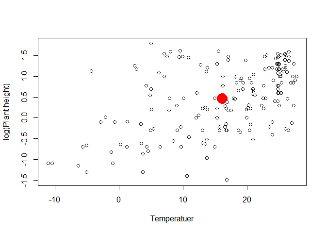

```r
plot(dtf$temp, dtf$loght, xlab = "Temperatuer", ylab = "log(Plant height)")
points(mean(dtf$temp), mean(dtf$loght), col = "red", pch = 16, cex = 3)
```

```r
b <- sum((dtf$temp - mean(dtf$temp)) * (dtf$loght - mean(dtf$loght))) / sum((dtf$temp - mean(dtf$temp)) ^ 2)
b
```

```
## [1] 0.04241362
```

```r
a <- mean(dtf$loght) - b * mean(dtf$temp)
a
```

```
## [1] -0.2256645
```

```r
mylm <- lm(loght ~ temp, dtf)
summary(mylm)
```

```
##
## Call:
## lm(formula = loght ~ temp, data = dtf)
##
## Residuals:
##      Min       1Q   Median       3Q      Max
## -1.97903 -0.42804 -0.00918  0.43200  1.79893
##
## Coefficients:
##              Estimate Std. Error t value         Pr(>|t|)
## (Intercept) -0.225665   0.103776  -2.175            0.031 *
## temp         0.042414   0.005593   7.583 0.00000000000187 ***
## ---
## Signif. codes:  0 '***' 0.001 '**' 0.01 '*' 0.05 '.' 0.1 ' ' 1
##
## Residual standard error: 0.6848 on 176 degrees of freedom
## Multiple R-squared:  0.2463, Adjusted R-squared:  0.242
## F-statistic:  57.5 on 1 and 176 DF,  p-value: 0.000000000001868
```

Hypotheses:

- $H_0$: There is no relationship between the temperature and log(plant height).
- $H_1$: There is relationship between the temperature and log(plant height).

Calculate a test statistic. $F$-test.

```r
dtf$predicted <- a + b * dtf$temp
# df
N <- nrow(dtf)
(dftot <- N - 1)
```

```
## [1] 177
```

```r
(dfres <- N - 2)
```

```
## [1] 176
```

```r
(dfreg <- 1)
```

```
## [1] 1
```

```r
dftot - dfres
```

```
## [1] 1
```

```r
# SS
(SStot <- sum((dtf$loght - mean(dtf$loght)) ^ 2))
```

```
## [1] 109.5073
```

```r
(SSres <- sum((dtf$loght - dtf$predicted) ^2))
```

```
## [1] 82.5404
```

```r
(SSreg <- sum((dtf$predicted - mean(dtf$loght)) ^ 2))
```

```
## [1] 26.96691
```

```r
SSreg + SSres
```

```
## [1] 109.5073
```

```r
# MS
(MSreg <- SSreg / dfreg)
```

```
## [1] 26.96691
```

```r
(MSres <- SSres / dfres)
```

```
## [1] 0.4689796
```

```r
# F
(F_score <- MSreg / MSres)
```

```
## [1] 57.50126
```

```r
(F_critical <- qf(0.05, df1 = dfreg, df2 = dfres, lower.tail = FALSE))
```

```
## [1] 3.894838
```

```r
pf(F_score, df1 = dfreg, df2 = dfres, lower.tail = FALSE)
```

```
## [1] 0.000000000001867934
```

With 1 and 176 degrees of freedom and $\alpha = 0.05$, the critical value of $F$ is 3.894838. The calculated $F$ (57.5012552) is greater than the critical $F$, so the decision is to reject $H_0$. We can conclude that the regression line provides a good fit to the data in the sample.

Hypotheses:

- $H_0: \beta = 0$. The slope of the regression line is zero.
- $H_1: \beta \ne 0$. The slope of the regression line is not zero.

Calculate a test statistic. $t$-test.

```r
dtf$residual <- dtf$loght - dtf$predicted
syx <- sqrt(sum(dtf$residual ^ 2) / (nrow(dtf) - 2))
(sx <- sd(dtf$temp))
```

```
## [1] 9.202879
```

```r
(sb <- syx/(sx * sqrt(N-1)))
```

```
## [1] 0.005593281
```

```r
beta <- 0
b
```

```
## [1] 0.04241362
```

```r
(t_score <- (b-beta) /sb)
```

```
## [1] 7.582958
```

```r
(t_critical <- qt(0.975, df = N-2))
```

```
## [1] 1.973534
```

```r
pt(t_score, df = N - 2, lower.tail = FALSE) * 2
```

```
## [1] 0.000000000001867934
```

With 176 degrees of freedom and $\alpha = 0.05$, the critical value of $t$ is 1.9735344. The calculated $t$ (7.5829582) is greater than the critical $t$, so the decision is to reject $H_0$. We can conclude that the slope of the regression line is not equal to 0.

Hypotheses:

- $H_0: \alpha = 0$. The intercept of the regression line is zero.
- $H_1: \alpha \ne 0$. The intercept of the regression line is not zero.

Calculate a test statistic. $t$-test.

```r
syx
```

```
## [1] 0.6848208
```

```r
N
```

```
## [1] 178
```

```r
(xbar <- mean(dtf$temp))
```

```
## [1] 16.12528
```

```r
sx
```

```
## [1] 9.202879
```

```r
(sa <- syx * sqrt(1/N + xbar ^2 / ((N-1) * sx^2)))
```

```
## [1] 0.1037764
```

```r
alpha <- 0
a
```

```
## [1] -0.2256645
```

```r
(t_score <- (a-alpha) /sa)
```

```
## [1] -2.174527
```

```r
(t_critical <- qt(0.025, df = N-1))
```

```
## [1] -1.973457
```

```r
pt(t_score, df = N - 2) * 2
```

```
## [1] 0.03100016
```

With 177 degrees of freedom and $\alpha = 0.05$, the critical value of $t$ is -1.9734572. The calculated $t$ (-2.1745269) is less than the critical $t$, so the decision is to reject $H_0$. We can conclude that the intercept of the regression line is not equal to 0.

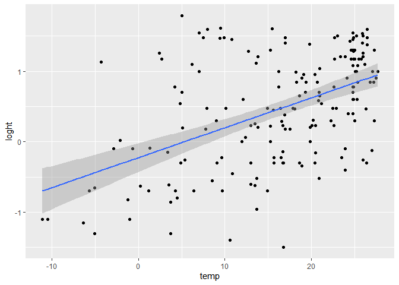

```r
library(ggplot2)
ggplot(dtf, aes(temp, loght)) + geom_point() + geom_smooth(method = "lm")
```